# Testes de hipóteses com duas amostras

Probest

fnaufel

(v. 17/09/2021)

# 1 Diferença entre proporções

## 1.1 Exemplo: jovens *online*

Duas amostras:

- $141$ de $248$ rapazes com idades entre $15$ e $17$ anos possuem um perfil *online*.
- $179$ de $256$ meninas com idades entre $15$ e $17$ anos possuem um perfil *online*.

A diferença entre as proporções é significativa?

### Condições

- As mesmas condições de testes com uma amostra precisam ser verificadas:
  - Independência.
  - Amostras aleatórias e representativas.
  - Tamanho da amostra menor que $10\%$ da população.
- E mais:
  - Independência dos grupos.
  - Cada grupo deve ter no mínimo $10$ sucessos e $10$ fracassos.

### Hipóteses

- O teste, agora, é sobre a diferença entre as proporções:

  $$H_0 : p_h - p_m = 0 \\
  H_A : p_h - p_m \neq 0$$

### Erro padrão

- A diferença $p_h - p_m$ é uma variável aleatória.
- A variância da diferença é a soma das variâncias:

  $$\sigma^2_{p_h - p_m} = \sigma^2_{p_h} + \sigma^2_{p_m}$$
- A variância da proporção amostral é

  $$\sigma^2(\hat p) = \frac{p(1 - p)}{n}$$
- Logo, a variância da diferença $p_h - p_m$ será

  $$\sigma^2(\hat p_h - \hat p_m)
  = \frac{p_h(1 - p_h)}{n_h} + \frac{p_m(1 - p_m)}{n_m}$$
- Daí, o desvio padrão da distribuição amostral da diferença é

  $$\sigma(\hat p_h - \hat p_m)
  = \sqrt{\frac{p_h(1 - p_h)}{n_h} + \frac{p_m(1 - p_m)}{n_m}}$$
- Como não sabemos os valores verdadeiros de $p_h$ e $p_m$, usamos as proporções amostrais para obter o erro padrão:

  $$EP(\hat p_h - \hat p_m)
  = \sqrt{\frac{\hat p_h(1 - \hat p_h)}{n_h} + \frac{\hat p_m(1 - \hat p_m)}{n_m}}$$
- Se fôssemos construir um intervalo de confiança, usaríamos este erro padrão.
- Mas, em um teste de hipóteses, estamos supondo que $H_0$ é verdadeira, o que equivale a dizer que $p_h = p_m$.
- Então, podemos calcular uma proporção ponderada, ou agregada:

  $$\bar p = \frac{\text{sucessos}_h + \text{sucessos}_m}{n_h + n_m}$$
- Aí, calculamos o erro padrão com este valor em vez de $\hat p_h$ e $\hat p_m$:

  $$EP(\hat p_h - \hat p_m)
  = \sqrt{\frac{\bar p(1 - \bar p)}{n_h} + \frac{\bar p(1 - \bar p)}{n_m}}$$

### Valores

- Tamanhos das amostras: $n_h = 248$ e $n_m = 256$.
- Proporções amostrais: $\hat p_h = 0{,}57$ e $\hat p_m = 0{,}7$.
- Hipótese de nulidade: $H_0 : p_h - p_m = 0$.
- Hipótese alternativa: $H_A : p_h - p_m \neq 0$.
- Nível de significância: $\alpha = 0{,}05$.

### Cálculos

```r
n_h <- 248
sucessos_h <- 141
p_h <- sucessos_h / n_h

n_m <- 256
sucessos_m <- 179
p_m <- sucessos_m / n_m

d0 <- 0
d_chapeu <- p_m - p_h
d_cauda_esquerda <- d0 - (d_chapeu - d0)

p_agregado <- (sucessos_h + sucessos_m) / (n_h + n_m)

ep <- sqrt(
  p_agregado * (1 - p_agregado) / n_h +
  p_agregado * (1 - p_agregado) / n_m
)

ep
```

```
## [1] 0,04289659
```

### A distribuição amostral de $\hat p_h - \hat p_m$, supondo $H_0$

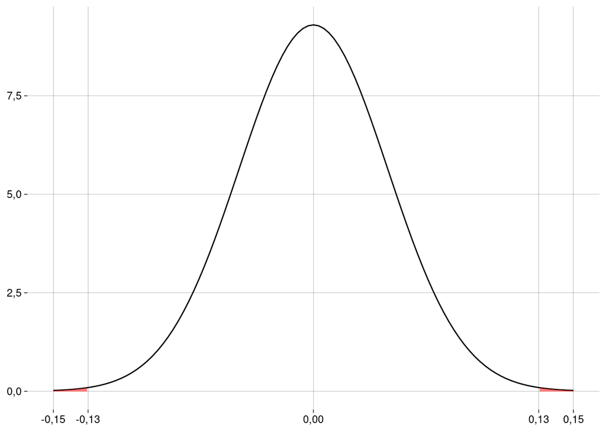

### Valor $p$ e conclusão

```r
valor_p <-
  pnorm(d_cauda_esquerda, mean = d0, sd = ep) +
  pnorm(d_chapeu, mean = d0, sd = ep, lower.tail = FALSE)
valor_p
```

```
## [1] 0,002317759
```

- Este valor é menor do que $\alpha = 0{,}05$. Logo, nossa amostra é evidência para rejeitar a hipótese de nulidade neste nível de significância.

## 1.2 Em R

```r
prop.test(
  x = c(sucessos_m, sucessos_h),
  n = c(n_m, n_h),
  alternative = 'two.sided',
  correct = FALSE
)
```

```
##
##  2-sample test for equality of proportions without continuity
##  correction
##
## data:  c(sucessos_m, sucessos_h) out of c(n_m, n_h)
## X-squared = 9,2792, df = 1, p-value = 0,002318
## alternative hypothesis: two.sided
## 95 percent confidence interval:
##  0,04727054 0,21407019
## sample estimates:
##    prop 1    prop 2
## 0,6992188 0,5685484
```

# 2 Diferença entre médias (amostras independentes)

## 2.1 Exemplo: olhos $\times$ flores

- Em $2006$, pesquisadores em uma universidade inglesa fizeram um experimento para verificar se as pessoas alteram seu comportamento quando se sentem vigiadas.
- Na universidade, havia uma copa onde chá, café e leite eram disponibilizados para todos que frequentavam o local.
- Na parede, próximo às bebidas, ficava um cartaz com as instruções para pagamento e os valores de cada bebida. As pessoas deviam depositar o dinheiro em uma caixa próxima às bebidas.
- Junto a esse cartaz, os pesquisadores afixaram outro, com imagens.
- As imagens eram trocadas regularmente. Durante uma semana, eram flores; durante uma semana, era um par de olhos. Esta alternância foi mantida durante $10$ semanas.
- A disposição da copa era tal que, se alguém decidisse não pagar, ninguém perceberia.
- Os pesquisadores controlaram a arrecadação por litro de leite consumido por semana.
- Em média, esta arrecadação foi quase $3$ vezes maior nas semanas em que o cartaz continha o par de olhos, em comparação com as semanas em que o cartaz continha as flores:

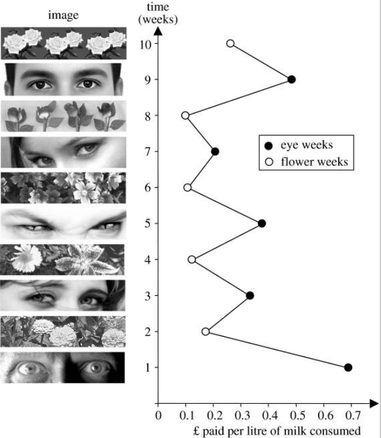

- Este exemplo é baseado em https://www.ncbi.nlm.nih.gov/pmc/articles/PMC1686213/, de onde foi retirada a imagem acima.

### Amostras

- As $5$ semanas com os cartazes dos olhos formam uma amostra.
- Nessas semanas, a arrecadação média por litro de leite foi de $0{,}417$ libras, com desvio padrão de $0{,}1811$.
- As $5$ semanas com os cartazes das flores formam a outra amostra.
- Nessas semanas, a arrecadação média por litro de leite foi de $0{,}151$ libras, com desvio padrão de $0{,}067$.
- Em R:

  ```r
  amostra_1 <- c(0.6843, 0.3038, 0.3780, 0.2202, 0.4987)
  amostra_2 <- c(0.1737, 0.117, 0.1075, 0.0981, 0.2587)
  ```

### Condições

- Independência: vamos supor que as contribuições de uma pessoa são independentes das das outras.
- Amostras aleatórias e representativas: vamos supor que essas contribuições representam a população de interesse (contribuições de frequentadores e funcionários da universidade? de todos os cidadãos ingleses? de toda a humanidade?)
- Tamanho das amostras:
  - As amostras são menos do que $10\%$ da população.
  - As amostras são pequenas ($n_1 = n_2 = 5$). Precisamos ser cautelosos quanto às conclusões.
- Independência dos grupos: o comportamento das pessoas nas semanas dos olhos é independente do comportamento *das mesmas pessoas* nas semanas das flores? Vamos supor que sim, embora esta seja uma suposição arriscada.
- Dados aproximadamente normais: com amostras tão pequenas, é difícil avaliar.
  - Para as semanas dos olhos:

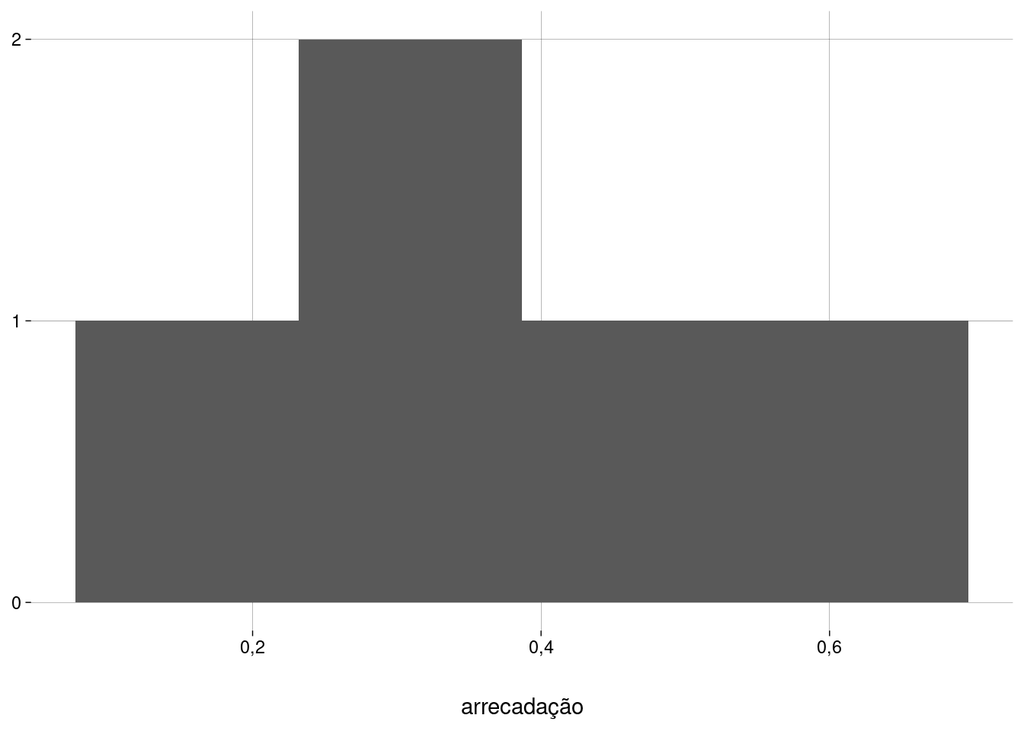

  - Para as semanas das flores:

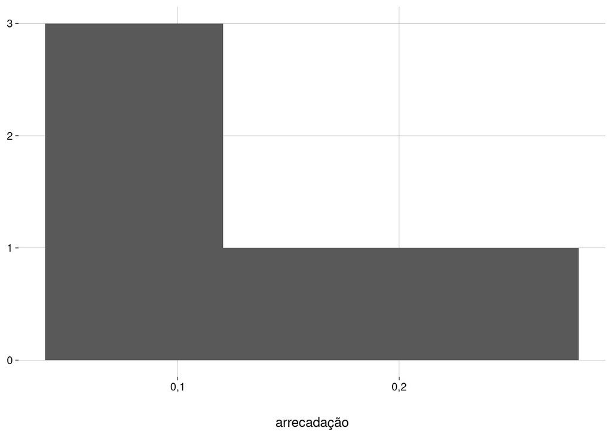

  - Agregando as duas amostras:

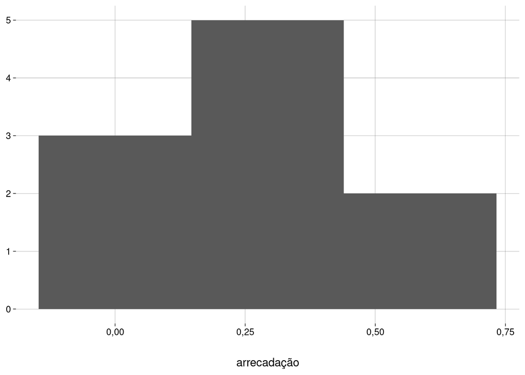

  - Pelo menos o terceiro histograma (com a união das duas amostras) é unimodal e simétrico. Vamos prosseguir com cautela.

### Hipóteses

- O teste, agora, é sobre a diferença entre as médias:

  $$H_0 : \mu_1 - \mu_2 = 0 \\
  H_A : \mu_1 - \mu_2 \neq 0$$

  onde $\mu_1$ é a média da arrecadação nas semanas dos olhos, e $\mu_2$ é a média da arrecadação nas semanas das flores.

### Erro padrão (variâncias diferentes)

- Mesmo quando supomos $H_0$ — i.e., que as médias populacionais $\mu_1$ e $\mu_2$ são iguais — não podemos afirmar nada sobre os desvios padrão das duas subpopulações: as semanas dos olhos e as semanas das flores.
- Podemos estimar as variações das duas amostras criando um *boxplot*:

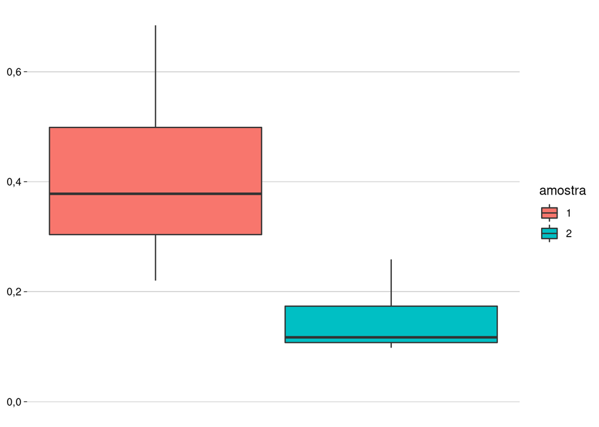

  A amostra $1$ parece ter uma variação maior do que a amostra $2$.
- De fato, o desvio padrão da amostra $1$ é quase o triplo do da amostra $2$.

  ```r
  sd(amostra_1)
  ```

  ```
  ## [1] 0,1811006
  ```

  ```r
  sd(amostra_2)
  ```

  ```
  ## [1] 0,06700978
  ```

- Então, estimamos a variância das semanas dos olhos por

  $$\hat \sigma^2_1 = \frac{s^2_1}{n_1}$$

  e estimamos a variância das semanas das flores por

  $$\hat \sigma^2_2 = \frac{s^2_2}{n_2}$$
- Daí, supondo $H_0$, a estimativa da variância populacional é

  $$\hat \sigma^2 = \frac{s^2_1}{n_1} + \frac{s^2_2}{n_2}$$
- E o erro padrão será

  $$EP = \sqrt{\frac{s^2_1}{n_1} + \frac{s^2_2}{n_2}}$$

### Valores

- Tamanhos das amostras: $n_1 = n_2 = 5$.
- Médias amostrais: $\bar x_1 = 0{,}417$ e $\bar x_2 = 0{,}151$.
- Desvios padrão amostrais: $s_1 = 0{,}1811$ e $s_2 = 0{,}067$.
- Hipótese de nulidade: $H_0 : \mu_1 - \mu_2 = 0$.
- Hipótese alternativa: $H_A : \mu_1 - \mu_2 \neq 0$.
- Nível de significância: $\alpha = 0{,}05$.

### Cálculos

```r
n_1 <- length(amostra_1)
xbarra_1 <- mean(amostra_1)
s_1 <- sd(amostra_1)

n_2 <- length(amostra_2)
xbarra_2 <- mean(amostra_2)
s_2 <- sd(amostra_2)

d0 <- 0
dx <- xbarra_1 - xbarra_2
d_cauda_esquerda <- d0 - dx

ep <- sqrt(s_1^2 / n_1 + s_2^2 / n_2)
ep
```

```
## [1] 0,08635708
```

### A distribuição amostral de $\bar x_1 - \bar x_2$, supondo $H_0$

- Como não sabemos o desvio padrão populacional, precisamos usar a distribuição $t$.
- A média da distribuição $t$ é $0$. Precisamos padronizar os valores:

  ```r
  dx
  ```

  ```
  ## [1] 0,266
  ```

  ```r
  tx <- (dx - d0)/ep
  tx
  ```

  ```
  ## [1] 3,080234
  ```

  ```r
  t_cauda_esquerda <- (d_cauda_esquerda - d0)/ep
  ```

- Quantos graus de liberdade?

  O número de graus de liberdade é dado por

  $$\nu = \frac{
  \left( \frac{s_1^2}{n_1} + \frac{s_2^2}{n_2} \right)^2
  }{
  \frac{(s_1^2 / n_1)^2}{n_1 - 1} +
  \frac{(s_2^2 / n_2)^2}{n_2 - 1}
  }$$

  ```r
  gl <- (s_1^2 / n_1 + s_2^2 / n_2)^2 / (
    (s_1^2 / n_1)^2 / (n_1 - 1) +
    (s_2^2 / n_2)^2 / (n_2 - 1)
  )

  gl
  ```

  ```
  ## [1] 5,075131
  ```

- Graficamente:

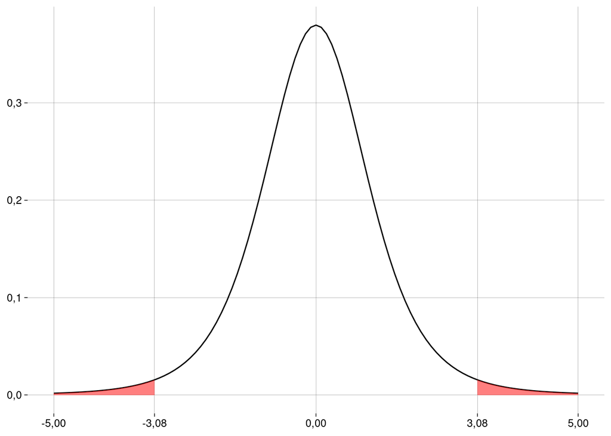

### Valor $p$ e conclusão

```r
valor_p <-
  pt(t_cauda_esquerda, gl) +
  pt(tx, gl, lower.tail = FALSE)

valor_p
```

```
## [1] 0,02692873
```

- Este valor é menor do que $\alpha = 0{,}05$. Logo, nossa amostra é evidência para rejeitar a hipótese de nulidade neste nível de significância.

## 2.2 Em R

```r
t.test(amostra_1, amostra_2)
```

```
##
##  Welch Two Sample t-test
##
## data:  amostra_1 and amostra_2
## t = 3,0802, df = 5,0751, p-value = 0,02693
## alternative hypothesis: true difference in means is not equal to 0
## 95 percent confidence interval:
##  0,04499686 0,48700314
## sample estimates:
## mean of x mean of y
##     0,417     0,151
```

## 2.3 E se as arrecadações médias tiverem o mesmo $\sigma$?

- O cálculo do erro padrão muda.
- A variância agregada é

  $$s^2 = \frac{(n_1 - 1)s_1^2}{(n_1 + n_2 - 2)} +
  \frac{(n_2 - 1)s_2^2}{(n_1 + n_2 - 2)}$$
- O erro padrão fica

  $$EP = \sqrt{\frac{s^2}{n_1} + \frac{s^2}{n_2}}$$

  onde $s^2$ é a variância agregada, calculada acima.

  ```r
  var_agregada <- (
    (n_1 - 1) * var(amostra_1) + (n_2 - 1) * var(amostra_2)
  ) / (n_1 + n_2 - 2)

  ep <- sqrt(var_agregada / n_1 + var_agregada / n_2)
  ep
  ```

  ```
  ## [1] 0,08635708
  ```

- O número de graus de liberdade fica mais simples:

  ```r
  gl <- n_1 + n_2 - 2
  gl
  ```

  ```
  ## [1] 8
  ```

- Refazendo os cálculos:

  ```r
  tx <- (dx - d0)/ep
  tx
  ```

  ```
  ## [1] 3,080234
  ```

  ```r
  t_cauda_esquerda <- (d_cauda_esquerda - d0)/ep

  valor_p <-
    pt(t_cauda_esquerda, gl) +
    pt(tx, gl, lower.tail = FALSE)

  valor_p
  ```

  ```
  ## [1] 0,01511156
  ```

- Supondo o mesmo desvio padrão para as duas subpopulações, o valor $p$ fica ainda menor. Como o valor é menor do que $\alpha = 0{,}05$, nossa amostra é evidência para rejeitar a hipótese de nulidade neste nível de significância.
- Em R:

  ```r
  t.test(amostra_1, amostra_2, var.equal = TRUE)
  ```

  ```
  ##
  ##  Two Sample t-test
  ##
  ## data:  amostra_1 and amostra_2
  ## t = 3,0802, df = 8, p-value = 0,01511
  ## alternative hypothesis: true difference in means is not equal to 0
  ## 95 percent confidence interval:
  ##  0,06686022 0,46513978
  ## sample estimates:
  ## mean of x mean of y
  ##     0,417     0,151
  ```

# 3 Diferença entre médias (amostras pareadas)

## 3.1 Exemplo: quilometragem

- Durante um ano, um órgão público mediu a quilometragem total de seus $11$ motoristas em um regime de trabalho de $5$ dias por semana.
- No ano seguinte, os mesmos $11$ motoristas trabalharam $4$ dias por semana, e as quilometragens totais foram medidas novamente.
- Os resultados foram:

  | motorista | dias_5 | dias_4 | diferença |
  | --- | --- | --- | --- |
  | 1 | 2798 | 2914 | -116 |
  | 2 | 7724 | 6112 | 1612 |
  | 3 | 7505 | 6177 | 1328 |
  | 4 | 838 | 1102 | -264 |
  | 5 | 4592 | 3281 | 1311 |
  | 6 | 8107 | 4997 | 3110 |
  | 7 | 1228 | 1695 | -467 |
  | 8 | 8718 | 6606 | 2112 |
  | 9 | 1097 | 1063 | 34 |
  | 10 | 8089 | 6392 | 1697 |

  [output cut: 1 more lines]

- A diferença nas quilometragens foi significativa?
- Exemplo baseado em https://www.thefreelibrary.com/Four-day+work+week+improves+environment.-a019280161
- As amostras agora são pareadas.
- O que nos interessa é a diferença na quilometragem de cada motorista.
- Vamos fazer um teste $t$ sobre as diferenças (os valores da última coluna).

### 3.1.1 Condições

- Independência entre os pares: o comportamento de cada motorista independe do comportamento dos outros.
- Amostras aleatórias e representativas: vamos supor que sim.
- Tamanho das amostras: as amostras são menos do que $10\%$ da população.
- Dados aproximadamente normais: vejamos um histograma das diferenças:

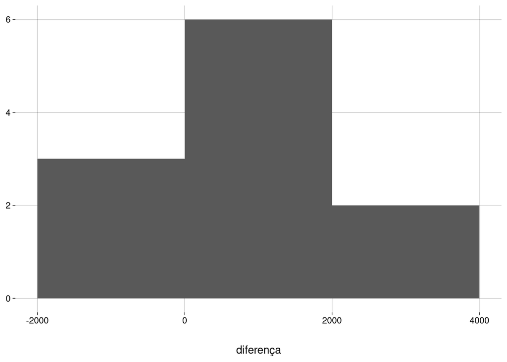

### 3.1.2 Hipóteses

- O teste, agora, é sobre a média das diferenças:

  $$H_0 : \mu_d = 0 \\
  H_A : \mu_d \neq 0$$

### 3.1.3 Erro padrão

- Como o erro padrão de $\mu$, mas, aqui, $n$ é o número de pares.

  $$EP = \frac{s_d}{\sqrt n}$$

  onde $s_d$ é o desvio padrão das diferenças.

### 3.1.4 Valores

- Tamanho da amostra: $n = 11$.
- Média amostral: $\bar d = 982$.
- Desvio padrão amostral: $s_d = 1.139{,}57$.
- Hipótese de nulidade: $H_0 : \mu_d = 0$.
- Hipótese alternativa: $H_A : \mu_d \neq 0$.
- Nível de significância: $\alpha = 0{,}05$.

### 3.1.5 Cálculos

```r
n <- length(df$diferença)
d_barra <- mean(df$diferença)
s_d <- sd(df$diferença)

d0 <- 0

ep <- s_d / sqrt(n)
ep
```

```
## [1] 343,5928
```

### 3.1.6 A distribuição amostral de $\bar d$

- Como não sabemos o desvio padrão populacional, precisamos usar a distribuição $t$.
- A média da distribuição $t$ é $0$. Precisamos padronizar os valores:

  ```r
  d_barra
  ```

  ```
  ## [1] 982
  ```

  ```r
  t_barra <- (d_barra - d0)/ep
  t_barra
  ```

  ```
  ## [1] 2,858034
  ```

- O número de graus de liberdade é $n - 1 = 10$.

  ```r
  gl <- n - 1
  ```

- Graficamente:

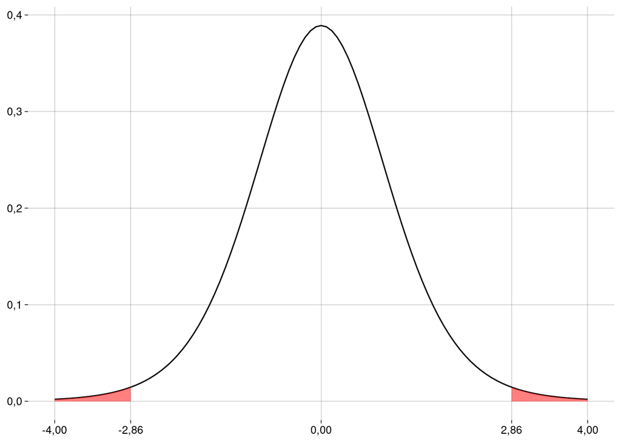

### 3.1.7 Valor $p$ e conclusão

```r
valor_p <- 2 * pt(t_barra, gl, lower.tail = FALSE)
valor_p
```

```
## [1] 0,01701413
```

- Este valor é menor do que $\alpha = 0{,}05$, nossa amostra é evidência para rejeitar a hipótese de nulidade neste nível de significância. A quilometragem média variou de um ano para o outro.

## 3.2 Em R

```r
t.test(
  df$dias_5,
  df$dias_4,
  paired = TRUE
)
```

```
##
##  Paired t-test
##
## data:  df$dias_5 and df$dias_4
## t = 2,858, df = 10, p-value = 0,01701
## alternative hypothesis: true difference in means is not equal to 0
## 95 percent confidence interval:
##   216,4276 1747,5724
## sample estimates:
## mean of the differences
##                     982
```

# 4 Outros testes em R

Diversas outras funções em R apresentam os resultados de testes em termos de intervalos de confiança e/ou valores $p$.

## 4.1 Teste de normalidade de Shapiro-Wilk

- A hipótese de nulidade é $H_0: {}$ a amostra vem de uma distribuição normal.
- Então, um valor $p$ alto é evidência a favor da normalidade dos dados:

  ```r
  x <- rnorm(100, 5, 3)
  shapiro.test(x)
  ```

  ```
  ##
  ##  Shapiro-Wilk normality test
  ##
  ## data:  x
  ## W = 0,99133, p-value = 0,7708
  ```

  ```r
  x <- runif(100, 0, 1)
  shapiro.test(x)
  ```

  ```
  ##
  ##  Shapiro-Wilk normality test
  ##
  ## data:  x
  ## W = 0,94083, p-value = 0,0002166
  ```

## 4.2 Teste para comparar variâncias

- A hipótese de nulidade é $H_0 : \sigma^2_x / \sigma^2_y = r$, onde o valor *default* de $r$ é $1$.
- Testando as amostras do experimento olhos $\times$ flores:

  ```r
  var.test(amostra_1, amostra_2)
  ```

  ```
  ##
  ##  F test to compare two variances
  ##
  ## data:  amostra_1 and amostra_2
  ## F = 7,304, num df = 4, denom df = 4, p-value = 0,08003
  ## alternative hypothesis: true ratio of variances is not equal to 1
  ## 95 percent confidence interval:
  ##   0,7604789 70,1518943
  ## sample estimates:
  ## ratio of variances
  ##           7,304042
  ```

## 4.3 Teste de correlação

- A hipótese de nulidade é $H_0 : {}$ as variáveis (pareadas) $x$ e $y$ *não* são correlacionadas.
- Testando as amostras do exemplo dos motoristas:

  ```r
  cor.test(df$dias_4, df$dias_5)
  ```

  ```
  ##
  ##  Pearson's product-moment correlation
  ##
  ## data:  df$dias_4 and df$dias_5
  ## t = 13,671, df = 9, p-value = 0,0000002518
  ## alternative hypothesis: true correlation is not equal to 0
  ## 95 percent confidence interval:
  ##  0,9101992 0,9941362
  ## sample estimates:
  ##       cor
  ## 0,9767585
  ```